# Trabalho Prático 1 - ECDB

Brandão et al.

2026-04-19

# 1 Introdução

O presente trabalho utiliza o conjunto de dados **TCGA-PRAD** (The Cancer Genome Atlas - Prostate Adenocarcinoma), obtido a partir do Genomic Data Commons, complementado com dados clínicos. Este conjunto de dados é relevante por incluir informação de expressão génica e variáveis clínicas associadas, permitindo comparar tecido tumoral e tecido normal e explorar heterogeneidade tumoral.

# 2 Objetivos

- Carregar e pré-processar dados de expressão génica.
- Integrar dados clínicos.
- Realizar análise descritiva e estatística univariada.
- Fazer análise de expressão diferencial.
- Realizar análise de enriquecimento funcional.
- Aplicar métodos não supervisionados.

# 3 Pipeline de análise

1. Aquisição dos dados com `TCGAbiolinks`.
2. Extração da matriz de contagens e metadados.
3. Filtragem de amostras `TP` e `NT`.
4. Leitura e limpeza do ficheiro clínico.
5. Filtragem e normalização.
6. Análise descritiva.
7. Expressão diferencial.
8. Enriquecimento funcional.
9. PCA, MDS, heatmaps e clustering.

# 4 Fase 1 - Extração e preparação

```r
library(TCGAbiolinks)
library(SummarizedExperiment)
library(edgeR)
library(DESeq2)
library(ggplot2)
library(dplyr)
library(cluster)

if (!requireNamespace("pheatmap", quietly = TRUE)) {
  stop("O pacote 'pheatmap' nao esta instalado.")
}
library(pheatmap)

if (!requireNamespace("clusterProfiler", quietly = TRUE)) {
  stop("O pacote 'clusterProfiler' nao esta instalado.")
}
if (!requireNamespace("org.Hs.eg.db", quietly = TRUE)) {
  stop("O pacote 'org.Hs.eg.db' nao esta instalado.")
}
if (!requireNamespace("enrichplot", quietly = TRUE)) {
  stop("O pacote 'enrichplot' nao esta instalado.")
}

library(clusterProfiler)
library(org.Hs.eg.db)
library(enrichplot)

set.seed(123)
```

## 4.1 Ficheiro clínico

## 4.2 Aquisição dos dados

```r
query <- GDCquery(
  project = "TCGA-PRAD",
  data.category = "Transcriptome Profiling",
  data.type = "Gene Expression Quantification",
  workflow.type = "STAR - Counts"
)

GDCdownload(query)
dados <- GDCprepare(query)
```

## 4.3 Extração dos dados

```r
contagens <- assay(dados, "unstranded")

meta <- as.data.frame(colData(dados))[, c(
  "shortLetterCode",
  "gender",
  "age_at_diagnosis",
  "vital_status"
)]

anot <- data.frame(
  ensembl = rownames(contagens),
  gene_name = rowData(dados)$gene_name,
  stringsAsFactors = FALSE
)

meta$sample_id <- rownames(meta)
```

## 4.4 Filtragem das amostras

```r
idx <- meta$shortLetterCode %in% c("TP", "NT")
contagens <- contagens[, idx, drop = FALSE]
meta <- meta[idx, , drop = FALSE]

meta$shortLetterCode <- factor(meta$shortLetterCode, levels = c("NT", "TP"))
rownames(meta) <- meta$sample_id
```

## 4.5 Leitura do ficheiro clínico

```r
clin <- read.delim(
  "prad_tcga_clinical_data.tsv",
  sep = "\t",
  stringsAsFactors = FALSE,
  check.names = FALSE
)

clin[clin == "NA"] <- NA

clin <- clin %>%
  rename(
    Patient_ID = `Patient ID`,
    Sample_ID = `Sample ID`,
    Diagnosis_Age = `Diagnosis Age`,
    Disease_Free_Status = `Disease Free Status`,
    Fraction_Genome_Altered = `Fraction Genome Altered`,
    Gleason_score = `Radical Prostatectomy Gleason Score for Prostate Cancer`
  )

clin$Diagnosis_Age <- suppressWarnings(as.numeric(clin$Diagnosis_Age))
clin$Gleason_score <- suppressWarnings(as.numeric(clin$Gleason_score))
clin$Fraction_Genome_Altered <- suppressWarnings(as.numeric(clin$Fraction_Genome_Altered))

clin$Disease_Free_Status <- gsub("^[0-9]+:", "", clin$Disease_Free_Status)
clin$Disease_Free_Status <- recode(
  clin$Disease_Free_Status,
  "DiseaseFree" = "Sem recidiva",
  "Recurred/Progressed" = "Recidiva/progressao",
  .default = clin$Disease_Free_Status
)
```

## 4.6 Filtragem de genes pouco expressos

```r
dge_tmp <- DGEList(counts = contagens)
keep <- filterByExpr(dge_tmp, group = meta$shortLetterCode)

contagens <- contagens[keep, , drop = FALSE]
anot <- anot[match(rownames(contagens), anot$ensembl), , drop = FALSE]

rm(dge_tmp, dados)
gc()
```

```
##            used  (Mb) gc trigger   (Mb)   max used   (Mb)
## Ncells  9172859 489.9   16621824  887.8   16621824  887.8
## Vcells 24372520 186.0  854897101 6522.4 1068611344 8152.9
```

## 4.7 Normalização

```r
dge <- DGEList(counts = contagens)
dge <- calcNormFactors(dge, method = "TMM")
logcpm <- cpm(dge, log = TRUE, prior.count = 1)
```

## 4.8 Sumarização descritiva

```r
table(meta$shortLetterCode)
```

```
##
##  NT  TP
##  52 501
```

```r
table(meta$gender)
```

```
##
## male
##  553
```

```r
summary(meta$age_at_diagnosis)
```

```
##    Min. 1st Qu.  Median    Mean 3rd Qu.    Max.    NA's
##   15884   20671   22568   22487   24315   28721      53
```

```r
table(meta$vital_status)
```

```
##
## Alive  Dead
##   543    10
```

```r
summary(clin$Diagnosis_Age)
```

```
##    Min. 1st Qu.  Median    Mean 3rd Qu.    Max.
##   41.00   56.00   61.00   61.01   66.00   78.00
```

```r
table(clin$Gleason_score, useNA = "ifany")
```

```
##
##   6   7   8   9  10
##  45 250  64 138   4
```

```r
table(clin$Disease_Free_Status, useNA = "ifany")
```

```
##
## Recidiva/progressao        Sem recidiva                <NA>
##                  92                 403                   6
```

## 4.9 Gráficos iniciais

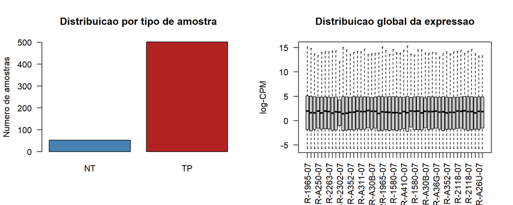

```r
par(mfrow = c(1, 2))

barplot(
  table(meta$shortLetterCode),
  col = c("steelblue", "firebrick"),
  main = "Distribuicao por tipo de amostra",
  ylab = "Numero de amostras",
  las = 1
)

boxplot(
  logcpm[, 1:min(50, ncol(logcpm)), drop = FALSE],
  outline = FALSE,
  las = 2,
  col = "gray80",
  main = "Distribuicao global da expressao",
  ylab = "log-CPM"
)
```

```r
par(mfrow = c(1, 1))
```

## 4.10 Genes de interesse

```r
genes_interesse <- c("PCA3", "KLK3")

ids_interesse <- sapply(genes_interesse, function(g) {
  x <- anot$ensembl[anot$gene_name == g]
  if (length(x) > 0) x else NA[2]
})

expr_pca3 <- if (!is.na(ids_interesse["PCA3"])) logcpm[ids_interesse["PCA3"], ] else NULL
expr_klk3 <- if (!is.na(ids_interesse["KLK3"])) logcpm[ids_interesse["KLK3"], ] else NULL

if (!is.null(expr_pca3)) {
  dados_pca3 <- data.frame(
    expressao = as.numeric(expr_pca3),
    grupo = meta$shortLetterCode
  )
}

if (!is.null(expr_klk3)) {
  dados_klk3 <- data.frame(
    expressao = as.numeric(expr_klk3),
    grupo = meta$shortLetterCode
  )
}
```

## 4.11 Boxplots

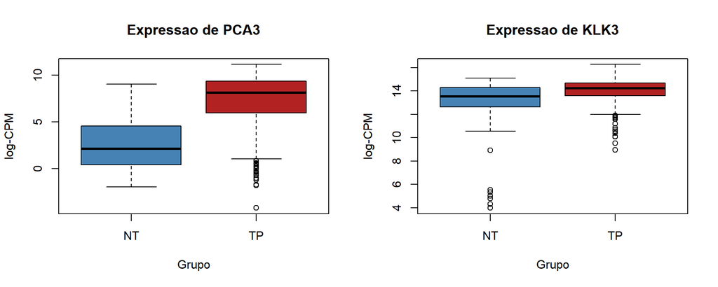

```r
par(mfrow = c(1, 2))

if (!is.null(expr_pca3)) {
  boxplot(
    expressao ~ grupo,
    data = dados_pca3,
    col = c("steelblue", "firebrick"),
    main = "Expressao de PCA3",
    ylab = "log-CPM",
    xlab = "Grupo"
  )
} else {
  plot.new()
  text(0.5, 0.5, "PCA3 nao encontrado")
}

if (!is.null(expr_klk3)) {
  boxplot(
    expressao ~ grupo,
    data = dados_klk3,
    col = c("steelblue", "firebrick"),
    main = "Expressao de KLK3",
    ylab = "log-CPM",
    xlab = "Grupo"
  )
} else {
  plot.new()
  text(0.5, 0.5, "KLK3 nao encontrado")
}
```

```r
par(mfrow = c(1, 1))
```

## 4.12 Testes de Wilcoxon

```r
if (!is.null(expr_pca3)) {
  print(wilcox.test(expressao ~ grupo, data = dados_pca3))
}
```

```
##
##  Wilcoxon rank sum test with continuity correction
##
## data:  expressao by grupo
## W = 3529, p-value < 2.2e-16
## alternative hypothesis: true location shift is not equal to 0
```

```r
if (!is.null(expr_klk3)) {
  print(wilcox.test(expressao ~ grupo, data = dados_klk3))
}
```

```
##
##  Wilcoxon rank sum test with continuity correction
##
## data:  expressao by grupo
## W = 8432, p-value = 2.808e-05
## alternative hypothesis: true location shift is not equal to 0
```

## 4.13 Expressão diferencial

```r
dds <- DESeqDataSetFromMatrix(
  countData = round(contagens),
  colData = meta,
  design = ~ shortLetterCode
)

dds <- DESeq(dds, quiet = TRUE)

res <- results(dds, contrast = c("shortLetterCode", "TP", "NT"))
res <- res[order(res$padj), ]

res_df <- as.data.frame(res)
res_df$ensembl <- rownames(res_df)

res_annot <- merge(res_df, anot, by = "ensembl", all.x = TRUE)

res_annot$significativo <- ifelse(
  !is.na(res_annot$padj) &
    res_annot$padj < 0.05 &
    abs(res_annot$log2FoldChange) > 1,
  "Significativo",
  "Nao significativo"
)

table(res_annot$significativo)
```

```
##
## Nao significativo     Significativo
##             20741              4545
```

```r
head(res_annot[order(res_annot$padj), c("ensembl", "gene_name", "log2FoldChange", "padj")], 20)
```

```
##                  ensembl gene_name log2FoldChange          padj
## 11396 ENSG00000168389.18    MFSD2A      -6.026735 2.102237e-159
## 14669 ENSG00000188488.14  SERPINA5      -6.810851 1.654719e-152
## 10519 ENSG00000164398.15     ACSL6      -4.970114 2.614136e-138
## 2512  ENSG00000101977.21      MCF2      -5.320128 1.769829e-126
## 1611  ENSG00000085662.14    AKR1B1      -3.931423 1.844825e-125
## 10973 ENSG00000166473.17    PKD1L2      -5.929874 6.428078e-123
## 11782 ENSG00000170370.12      EMX2      -6.823018 1.204120e-118
## 4755   ENSG00000120068.7     HOXB8      -6.322002 1.536775e-117
## 10728 ENSG00000165376.11     CLDN2      -7.966224 4.911162e-115
## 5624  ENSG00000128040.11    SPINK2      -7.470328 6.056039e-110
## 15252 ENSG00000197705.10    KLHL14      -4.289516 5.741519e-105
## 2644  ENSG00000103034.14     NDRG4      -3.406200 1.015720e-104
## 17998  ENSG00000229847.9    EMX2OS      -6.025554 3.877825e-102
## 9567  ENSG00000158955.11     WNT9B      -4.610836  4.461801e-95
## 22784  ENSG00000270885.2   RASL10B      -3.525431  7.406244e-95
## 15053  ENSG00000196844.9     PATE2      -5.487466  2.210005e-94
## 1977  ENSG00000095713.14    CRTAC1      -4.359947  7.007642e-91
## 3517  ENSG00000109667.12    SLC2A9      -2.747776  1.778882e-87
## 7082  ENSG00000137869.15   CYP19A1      -4.641615  1.917550e-86
## 10191 ENSG00000163364.10 LINC01116      -3.602444  1.040294e-84
```

## 4.14 Volcano plot

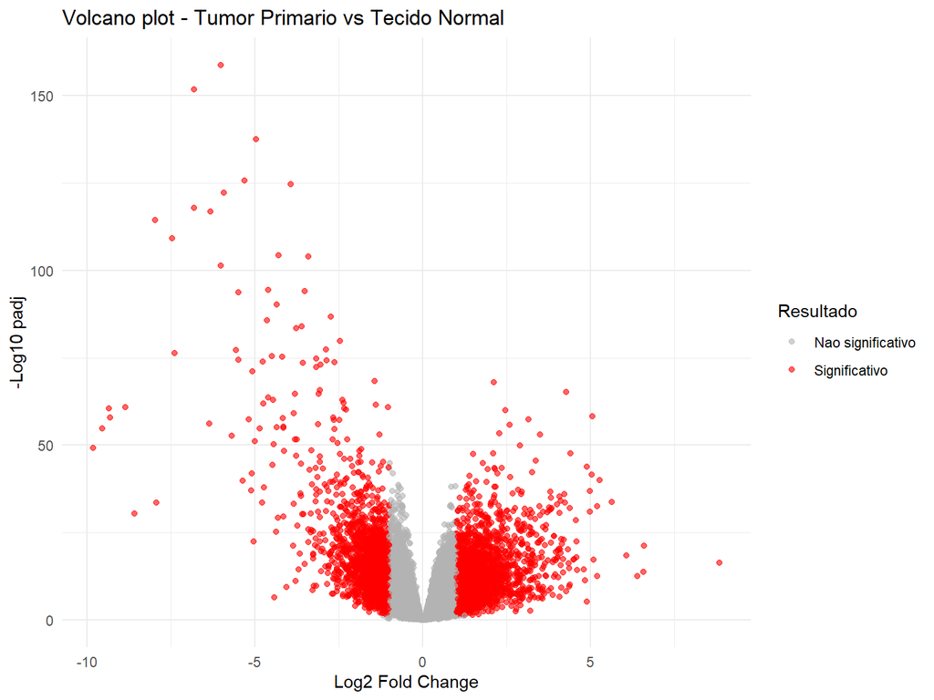

```r
volcano_df <- res_annot %>%
  filter(!is.na(log2FoldChange), !is.na(padj), padj > 0) %>%
  mutate(neglog10_padj = -log10(padj))

ggplot(volcano_df, aes(x = log2FoldChange, y = neglog10_padj, color = significativo)) +
  geom_point(alpha = 0.6) +
  scale_color_manual(values = c("Nao significativo" = "gray70", "Significativo" = "red")) +
  theme_minimal() +
  labs(
    title = "Volcano plot - Tumor Primario vs Tecido Normal",
    x = "Log2 Fold Change",
    y = "-Log10 padj",
    color = "Resultado"
  )
```

Volcano plot - Tumor vs Normal O volcano plot evidencia muitos genes diferencialmente expressos entre tumor e normal, tendo alterações significativas tanto para cima como para baixo, indicando assim mudanças transcricionais profundas associadas ao estado tumoral.

## 4.15 Gráficos clínicos

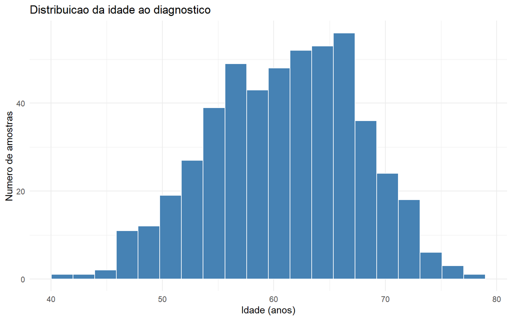

```r
ggplot(clin, aes(x = Diagnosis_Age)) +
  geom_histogram(bins = 20, fill = "steelblue", color = "white") +
  theme_minimal() +
  labs(
    title = "Distribuicao da idade ao diagnostico",
    x = "Idade (anos)",
    y = "Numero de amostras"
  )
```

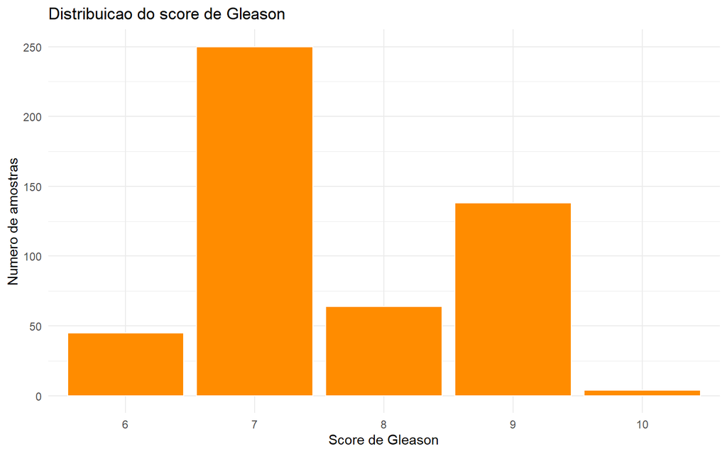

```r
ggplot(clin, aes(x = factor(Gleason_score))) +
  geom_bar(fill = "darkorange", color = "white") +
  theme_minimal() +
  labs(
    title = "Distribuicao do score de Gleason",
    x = "Score de Gleason",
    y = "Numero de amostras"
  )
```

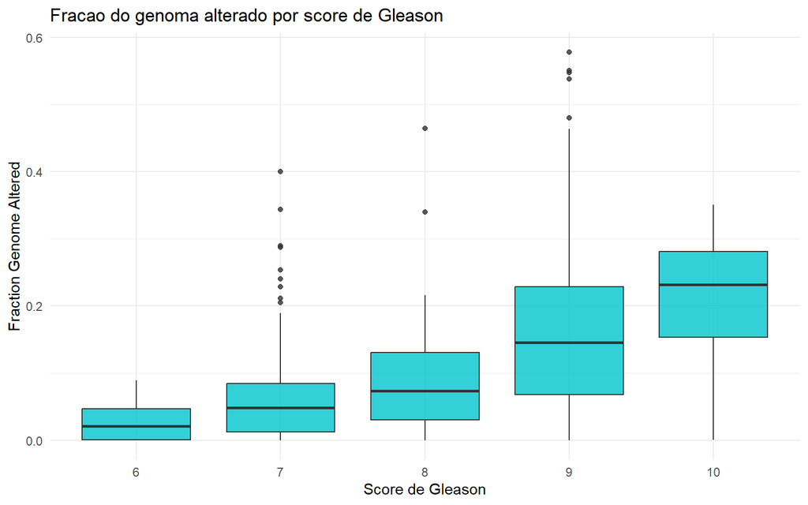

```r
clin2 <- clin %>%
  filter(!is.na(Fraction_Genome_Altered), !is.na(Gleason_score)) %>%
  mutate(Gleason = factor(Gleason_score, levels = sort(unique(Gleason_score))))

ggplot(clin2, aes(x = Gleason, y = Fraction_Genome_Altered)) +
  geom_boxplot(fill = "turquoise3", alpha = 0.8) +
  theme_minimal() +
  labs(
    title = "Fracao do genoma alterado por score de Gleason",
    x = "Score de Gleason",
    y = "Fraction Genome Altered"
  )
```

## 4.16 Enriquecimento funcional

```r
genes_sig <- res_annot %>%
  filter(!is.na(padj), padj < 0.05, abs(log2FoldChange) > 1, !is.na(gene_name), gene_name != "") %>%
  distinct(gene_name, .keep_all = TRUE)

gene_map <- bitr(
  genes_sig$gene_name,
  fromType = "SYMBOL",
  toType = "ENTREZID",
  OrgDb = org.Hs.eg.db
)

gene_entrez <- unique(gene_map$ENTREZID)
length(gene_entrez)
```

```
## [1] 3366
```

```r
ego <- enrichGO(
  gene = gene_entrez,
  OrgDb = org.Hs.eg.db,
  keyType = "ENTREZID",
  ont = "BP",
  pAdjustMethod = "BH",
  pvalueCutoff = 0.05,
  qvalueCutoff = 0.2,
  readable = TRUE
)

head(as.data.frame(ego), 15)
```

```
##                    ID
## GO:0006936 GO:0006936
## GO:0003012 GO:0003012
## GO:0098742 GO:0098742
## GO:0007156 GO:0007156
## GO:0007409 GO:0007409
## GO:0042391 GO:0042391
## GO:1903522 GO:1903522
## GO:0008016 GO:0008016
## GO:0003018 GO:0003018
## GO:0048562 GO:0048562
## GO:0060047 GO:0060047
## GO:0003015 GO:0003015
## GO:0007411 GO:0007411
## GO:0097485 GO:0097485
## GO:0007389 GO:0007389
##                                                                Description
## GO:0006936                                              muscle contraction
## GO:0003012                                           muscle system process
## GO:0098742       cell-cell adhesion via plasma-membrane adhesion molecules
## GO:0007156 homophilic cell adhesion via plasma membrane adhesion molecules
## GO:0007409                                                    axonogenesis
## GO:0042391                                regulation of membrane potential
## GO:1903522                                 regulation of blood circulation
## GO:0008016                                 regulation of heart contraction
## GO:0003018                          vascular process in circulatory system
## GO:0048562                                   embryonic organ morphogenesis
## GO:0060047                                               heart contraction
## GO:0003015                                                   heart process
## GO:0007411                                                   axon guidance
## GO:0097485                                      neuron projection guidance
## GO:0007389                                   pattern specification process
##            GeneRatio   BgRatio RichFactor FoldEnrichment    zScore       pvalue
## GO:0006936  117/2412 372/18860  0.3145161       2.459276 10.885677 1.762646e-21
## GO:0003012  136/2412 485/18860  0.2804124       2.192611 10.189371 9.789626e-20
## GO:0098742   91/2412 279/18860  0.3261649       2.550361  9.990603 3.968729e-18
## GO:0007156   63/2412 168/18860  0.3750000       2.932214  9.633263 3.180032e-16
## GO:0007409  125/2412 472/18860  0.2648305       2.070773  9.021784 4.193654e-16
## GO:0042391  122/2412 474/18860  0.2573840       2.012546  8.549719 9.341271e-15
## GO:1903522   84/2412 279/18860  0.3010753       2.354179  8.726399 1.449840e-14
```

[output cut: 41 more lines]

```
## GO:0006936   117
## GO:0003012   136
## GO:0098742    91
## GO:0007156    63
## GO:0007409   125
## GO:0042391   122
## GO:1903522    84
## GO:0008016    71
## GO:0003018    82
## GO:0048562    86
## GO:0060047    77
## GO:0003015    78
## GO:0007411    71
## GO:0097485    71
## GO:0007389   116
```

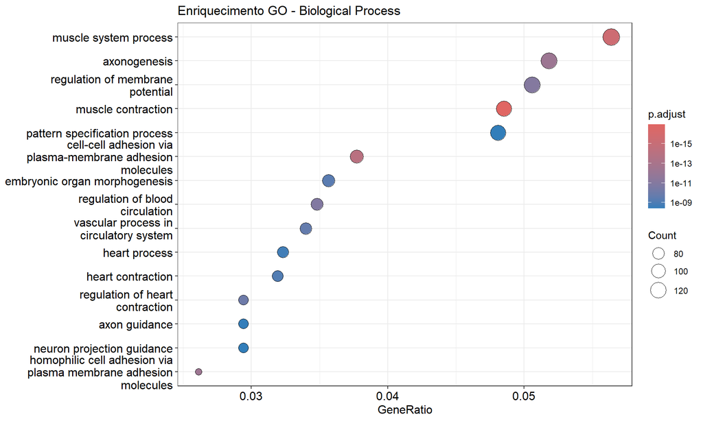

```r
if (!is.null(ego) && nrow(as.data.frame(ego)) > 0) {
  print(
    dotplot(ego, showCategory = 15) +
      ggtitle("Enriquecimento GO - Biological Process")
  )
}
```

```r
ekegg <- enrichKEGG(
  gene = gene_entrez,
  organism = "hsa",
  pvalueCutoff = 0.05
)

head(as.data.frame(ekegg), 15)
```

```
##                                      category
## hsa04080 Environmental Information Processing
## hsa04020 Environmental Information Processing
## hsa04519 Environmental Information Processing
## hsa04820                   Cellular Processes
## hsa05414                       Human Diseases
## hsa05410                       Human Diseases
## hsa05412                       Human Diseases
## hsa04082 Environmental Information Processing
## hsa04270                   Organismal Systems
## hsa04972                   Organismal Systems
## hsa05034                       Human Diseases
## hsa04022 Environmental Information Processing
## hsa04510                   Cellular Processes
## hsa04024 Environmental Information Processing
## hsa04976                   Organismal Systems
##                                  subcategory       ID
## hsa04080 Signaling molecules and interaction hsa04080
## hsa04020                 Signal transduction hsa04020
## hsa04519 Signaling molecules and interaction hsa04519
## hsa04820                       Cell motility hsa04820
## hsa05414              Cardiovascular disease hsa05414
## hsa05410              Cardiovascular disease hsa05410
## hsa05412              Cardiovascular disease hsa05412
## hsa04082 Signaling molecules and interaction hsa04082
## hsa04270                  Circulatory system hsa04270
## hsa04972                    Digestive system hsa04972
## hsa05034                Substance dependence hsa05034
## hsa04022                 Signal transduction hsa04022
## hsa04510     Cellular community - eukaryotes hsa04510
## hsa04024                 Signal transduction hsa04024
## hsa04976                    Digestive system hsa04976
##                                              Description GeneRatio  BgRatio
## hsa04080         Neuroactive ligand-receptor interaction  100/1211 370/9378
## hsa04020                       Calcium signaling pathway   73/1211 254/9378
## hsa04519                              Cadherin signaling   98/1211 404/9378
## hsa04820                    Cytoskeleton in muscle cells   64/1211 233/9378
## hsa05414                          Dilated cardiomyopathy   37/1211 105/9378
## hsa05410                     Hypertrophic cardiomyopathy   35/1211  99/9378
## hsa05412 Arrhythmogenic right ventricular cardiomyopathy   31/1211  86/9378
```

[output cut: 57 more lines]

```
## hsa04080   100
## hsa04020    73
## hsa04519    98
## hsa04820    64
## hsa05414    37
## hsa05410    35
## hsa05412    31
## hsa04082    54
## hsa04270    41
## hsa04972    33
## hsa05034    49
## hsa04022    43
## hsa04510    49
## hsa04024    53
## hsa04976    27
```

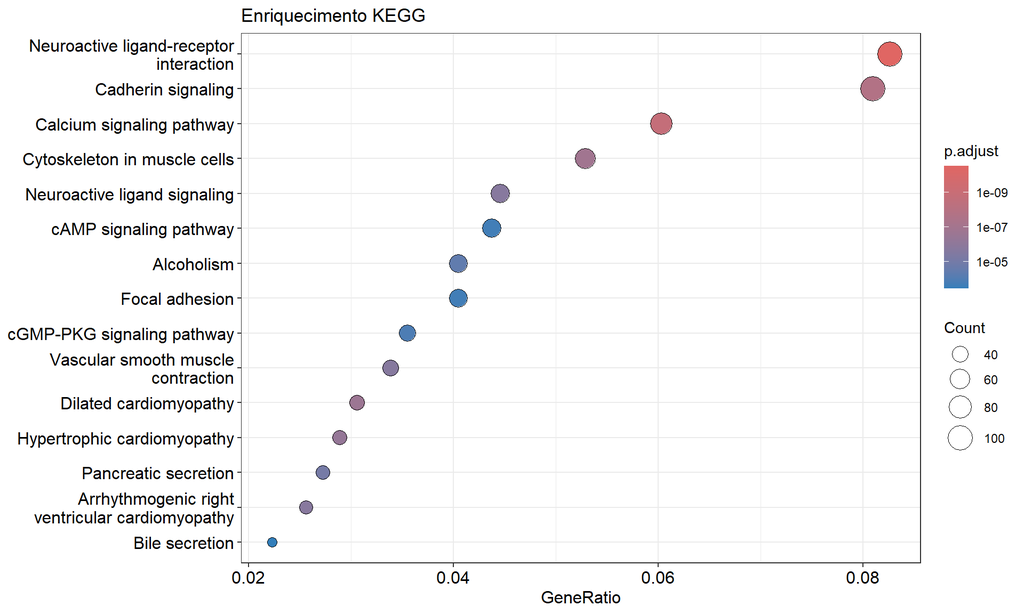

```r
if (!is.null(ekegg) && nrow(as.data.frame(ekegg)) > 0) {
  print(
    dotplot(ekegg, showCategory = 15) +
      ggtitle("Enriquecimento KEGG")
  )
}
```

# 5 Fase 2 - Análises não supervisionadas

## 5.1 Integração dos metadados clínicos

Para a fase 2 foi feita a integração entre os identificadores das amostras e variáveis clínicas relevantes, de forma a permitir posterior interpretação biológica dos clusters encontrados.

```r
meta2 <- meta
meta2$sample_id <- rownames(meta2)
meta2$patient_id <- substr(meta2$sample_id, 1, 12)
meta2$sample_short_id <- substr(meta2$sample_id, 1, 15)

clin_raw <- read.delim(
  "prad_tcga_clinical_data.tsv",
  sep = "\t",
  stringsAsFactors = FALSE,
  check.names = FALSE
)

clin_raw[clin_raw == "NA"] <- NA

clin_join <- clin_raw %>%
  transmute(
    patient_id = `Patient ID`,
    sample_id_clin = `Sample ID`,
    sample_short_id = substr(`Sample ID`, 1, 15),
    Diagnosis_Age = suppressWarnings(as.numeric(`Diagnosis Age`)),
    Gleason = suppressWarnings(as.numeric(`Radical Prostatectomy Gleason Score for Prostate Cancer`)),
    FGA = suppressWarnings(as.numeric(`Fraction Genome Altered`)),
    DFS_status = gsub("^[0-9]+:", "", `Disease Free Status`)
  ) %>%
  mutate(
    DFS_status = recode(
      DFS_status,
      "DiseaseFree" = "Sem recidiva",
      "Recurred/Progressed" = "Recidiva/progressao",
      .default = DFS_status
    )
  ) %>%
  distinct(sample_short_id, .keep_all = TRUE)

meta2 <- meta2%>%
  left_join(clin_join, by = c("patient_id", "sample_short_id"))

rownames(meta2) <- meta2$sample_id
```

## 5.2 Transformação VST

```r
dds_unsup <- DESeqDataSetFromMatrix(
  countData = round(contagens),
  colData = meta,
  design = ~ shortLetterCode
)

dds_unsup <- estimateSizeFactors(dds_unsup)
vst_mat <- assay(vst(dds_unsup, blind = TRUE))
```

## 5.3 Anotação dos genes

```r
gene_symbols <- anot$gene_name[match(rownames(vst_mat), anot$ensembl)]
gene_symbols <- as.character(gene_symbols)
gene_symbols[is.na(gene_symbols) | gene_symbols == ""] <- rownames(vst_mat)[is.na(gene_symbols) | gene_symbols == ""]
rownames(vst_mat) <- make.unique(gene_symbols)
```

## 5.4 Seleção dos genes mais variáveis

```r
gene_var_all <- apply(vst_mat, 1, var, na.rm = TRUE)
gene_var_all[is.na(gene_var_all)] <- 0

top500_all <- names(sort(gene_var_all, decreasing = TRUE))[1:min(500, length(gene_var_all))]
top50_all <- names(sort(gene_var_all, decreasing = TRUE))[1:min(50, length(gene_var_all))]

mat_pca_all <- vst_mat[top500_all, , drop = FALSE]
mat_heat_all <- vst_mat[top50_all, , drop = FALSE]

mat_pca_all <- mat_pca_all[
  apply(mat_pca_all, 1, function(x) var(x, na.rm = TRUE) > 0 && all(is.finite(x))),
  , drop = FALSE
]

mat_heat_all <- mat_heat_all[
  apply(mat_heat_all, 1, function(x) var(x, na.rm = TRUE) > 0 && all(is.finite(x))),
  , drop = FALSE
]

if (nrow(mat_pca_all) < 2 || ncol(mat_pca_all) < 2) {
  stop("Nao ha genes/amostras suficientes para PCA global.")
}
```

## 5.5 PCA global

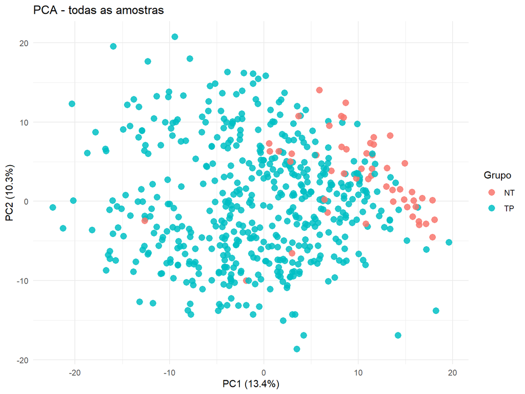

```r
# PCA - todas as amostras
pca_all <- prcomp(t(mat_pca_all), scale. = TRUE)

pca_all_df <- data.frame(
  sample_id = rownames(pca_all$x),
  PC1 = pca_all$x[, 1],
  PC2 = pca_all$x[, 2]
) %>%
  left_join(meta2, by = "sample_id")

var_exp <- summary(pca_all)$importance[2, 1:2] * 100

ggplot(pca_all_df, aes(x = PC1, y = PC2, color = shortLetterCode)) +
  geom_point(size = 3, alpha = 0.85) +
  theme_minimal() +
  labs(
    title = "PCA - todas as amostras",
    x = paste0("PC1 (", round(var_exp[1], 1), "%)"),
    y = paste0("PC2 (", round(var_exp[2], 1), "%)"),
    color = "Grupo"
  )
```

## 5.6 MDS global

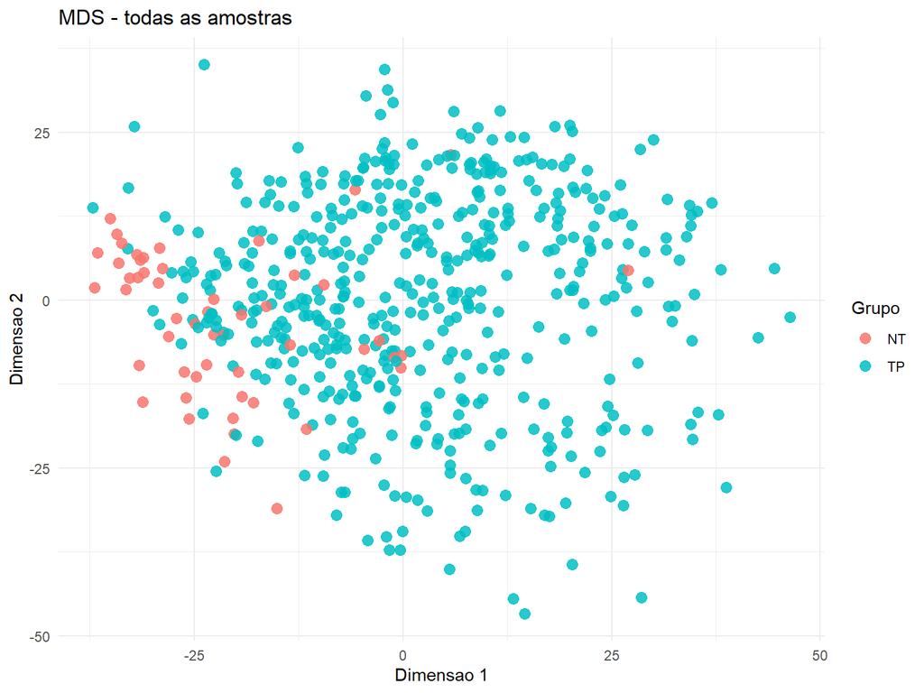

```r
dist_all <- dist(t(mat_pca_all))
mds_all <- cmdscale(dist_all, k = 2)

mds_all_df <- data.frame(
  sample_id = rownames(mds_all),
  Dim1 = mds_all[, 1],
  Dim2 = mds_all[, 2]
) %>%
  left_join(meta2, by = "sample_id")

ggplot(mds_all_df, aes(x = Dim1, y = Dim2, color = shortLetterCode)) +
  geom_point(size = 3, alpha = 0.85) +
  theme_minimal() +
  labs(
    title = "MDS - todas as amostras",
    x = "Dimensao 1",
    y = "Dimensao 2",
    color = "Grupo"
  )
```

## 5.7 Heatmap global

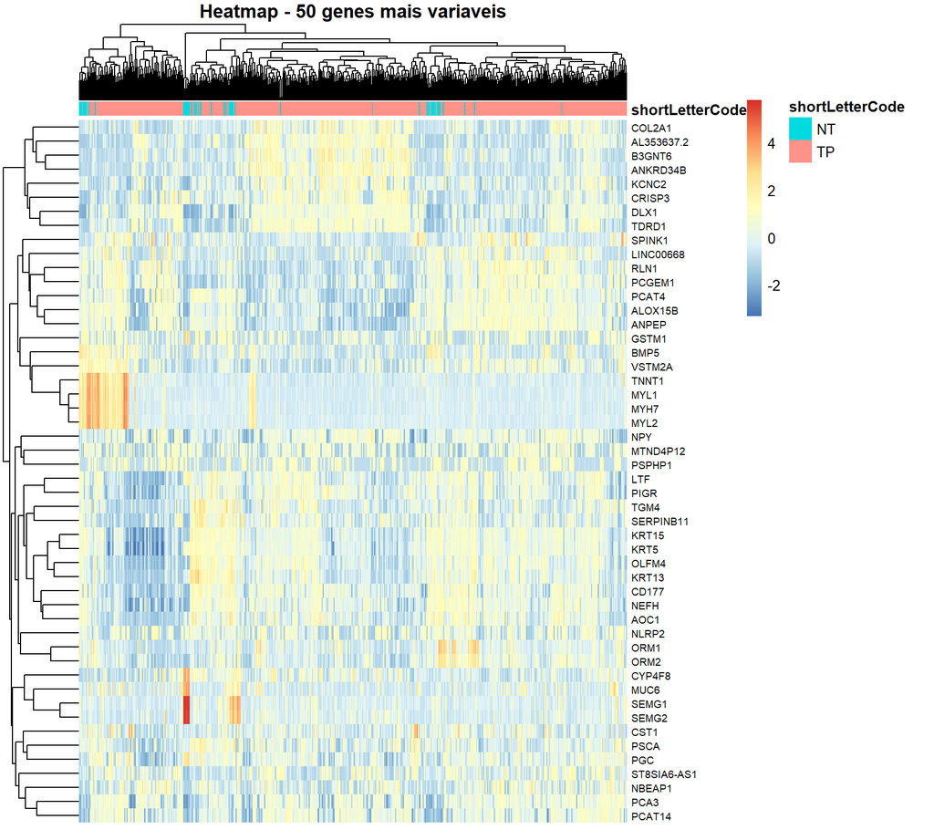

```r
mat_heat_all_z <- t(scale(t(mat_heat_all)))
mat_heat_all_z[!is.finite(mat_heat_all_z)] <- 0

ann_all <- meta2[, c("shortLetterCode"), drop = FALSE]
rownames(ann_all) <- meta2$sample_id
ann_all <- ann_all[colnames(mat_heat_all_z), , drop = FALSE]

pheatmap(
  mat_heat_all_z,
  annotation_col = ann_all,
  show_colnames = FALSE,
  fontsize_row = 7,
  main = "Heatmap - 50 genes mais variaveis"
)
```

## 5.8 Análise dos Tumores

```r
idx_tumor <- meta2$shortLetterCode == "TP"
vst_tumor <- vst_mat[, idx_tumor, drop = FALSE]
meta_tumor <- meta2[idx_tumor, , drop = FALSE]

if (ncol(vst_tumor) < 3) {
  stop("Poucas amostras tumorais para clustering.")
}

gene_var_tumor <- apply(vst_tumor, 1, var, na.rm = TRUE)
gene_var_tumor[is.na(gene_var_tumor)] <- 0

top500_tumor <- names(sort(gene_var_tumor, decreasing = TRUE))[1:min(500, length(gene_var_tumor))]
top50_tumor <- names(sort(gene_var_tumor, decreasing = TRUE))[1:min(50, length(gene_var_tumor))]

mat_pca_tumor <- vst_tumor[top500_tumor, , drop = FALSE]
mat_pca_tumor <- mat_pca_tumor[
  apply(mat_pca_tumor, 1, function(x) var(x, na.rm = TRUE) > 0 && all(is.finite(x))),
  , drop = FALSE
]

if (nrow(mat_pca_tumor) < 2 || ncol(mat_pca_tumor) < 3) {
  stop("Poucos genes/amostras validos para clustering tumoral.")
}
```

## 5.9 PCA tumoral e clustering

```r
pca_tumor <- prcomp(t(mat_pca_tumor), scale. = TRUE)
pc_scores <- pca_tumor$x[, 1:min(10, ncol(pca_tumor$x)), drop = FALSE]
```

```r
ks <- 2:min(6, nrow(pc_scores) - 1)

sil_means <- sapply(ks, function(k) {
  km <- kmeans(pc_scores, centers = k, nstart = 25)
  ss <- silhouette(km$cluster, dist(pc_scores))
  mean(ss[, 3])
})

best_k <- ks[which.max(sil_means)]
km_final <- kmeans(pc_scores, centers = best_k, nstart = 50)

meta_tumor$cluster <- factor(km_final$cluster)

sil_df <- data.frame(
  k = ks,
  silhouette_media = sil_means
)

sil_df
```

```
##   k silhouette_media
## 1 2        0.1669893
## 2 3        0.1708331
## 3 4        0.1598964
## 4 5        0.1664345
## 5 6        0.1514964
```

## 5.10 PCA tumoral colorido por cluster

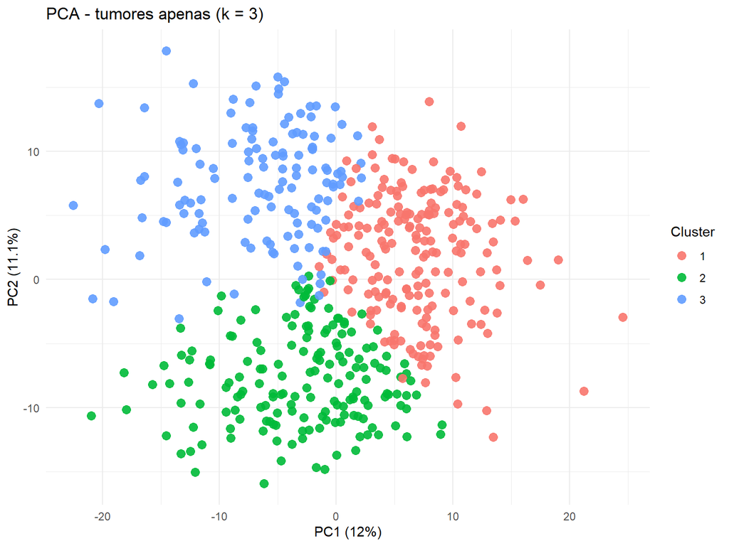

```r
pca_tumor_df <- data.frame(
  sample_id = rownames(pca_tumor$x),
  PC1 = pca_tumor$x[, 1],
  PC2 = pca_tumor$x[, 2]
) %>%
  left_join(meta_tumor, by = "sample_id")

var_exp_t <- summary(pca_tumor)$importance[2, 1:2] * 100

ggplot(pca_tumor_df, aes(x = PC1, y = PC2, color = cluster)) +
  geom_point(size = 3, alpha = 0.9) +
  theme_minimal() +
  labs(
    title = paste0("PCA - tumores apenas (k = ", best_k, ")"),
    x = paste0("PC1 (", round(var_exp_t[1], 1), "%)"),
    y = paste0("PC2 (", round(var_exp_t[2], 1), "%)"),
    color = "Cluster"
  )
```

## 5.11 Heatmap tumoral

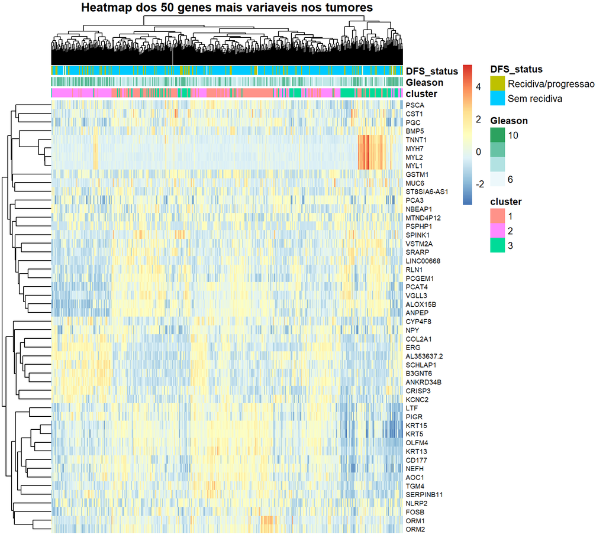

```r
mat_top50_tumor <- vst_tumor[top50_tumor, , drop = FALSE]
mat_top50_tumor_z <- t(scale(t(mat_top50_tumor)))
mat_top50_tumor_z[!is.finite(mat_top50_tumor_z)] <- 0

ann_tumor <- meta_tumor[, c("cluster", "Gleason", "DFS_status"), drop = FALSE]
rownames(ann_tumor) <- meta_tumor$sample_id
ann_tumor <- ann_tumor[colnames(mat_top50_tumor_z), , drop = FALSE]

pheatmap(
  mat_top50_tumor_z,
  annotation_col = ann_tumor,
  show_colnames = FALSE,
  fontsize_row = 7,
  main = "Heatmap dos 50 genes mais variaveis nos tumores"
)
```

Heatmap – 50 genes mais variáveis nos tumores Este heatmap mostra-nos que os padrões de expressão dos genes mais variáveis se alinham parcialmente com os clusters tumorais e com características clínicas como Gleason e recidiva, sugerindo relevância biológica e potencial valor prognóstico.

## 5.12 Relação exploratória com clínica

```r
print(table(Cluster = meta_tumor$cluster, Gleason = meta_tumor$Gleason, useNA = "ifany"))
```

```
##        Gleason
## Cluster   6   7   8   9  10
##       1  19 109  28  41   1
##       2  13  79  23  57   0
##       3  14  61  14  39   3
```

```r
print(table(Cluster = meta_tumor$cluster, DFS = meta_tumor$DFS_status, useNA = "ifany"))
```

```
##        DFS
## Cluster Recidiva/progressao Sem recidiva <NA>
##       1                  26          170    2
##       2                  36          134    2
##       3                  29          100    2
```

```r
meta_tumor_fga <- meta_tumor[!is.na(meta_tumor$cluster) & !is.na(meta_tumor$FGA), , drop = FALSE]

if (nrow(meta_tumor_fga) > 0) {
  print(aggregate(FGA ~ cluster, data = meta_tumor_fga, summary))
}
```

```
##   cluster   FGA.Min. FGA.1st Qu. FGA.Median   FGA.Mean FGA.3rd Qu.   FGA.Max.
## 1       1 0.00000000  0.00020000 0.02745000 0.06230306  0.08567500 0.53790000
## 2       2 0.00000000  0.04435000 0.07090000 0.09963684  0.13015000 0.57820000
## 3       3 0.00000000  0.03550000 0.08565000 0.12145156  0.17000000 0.46450000
```

```r
if (nrow(meta_tumor_fga) > 0 && length(unique(meta_tumor_fga$cluster)) > 1) {
  print(kruskal.test(FGA ~ cluster, data = meta_tumor_fga))
}
```

```
##
##  Kruskal-Wallis rank sum test
##
## data:  FGA by cluster
## Kruskal-Wallis chi-squared = 59.386, df = 2, p-value = 1.272e-13
```

## 5.13 Gráfico de silhouette

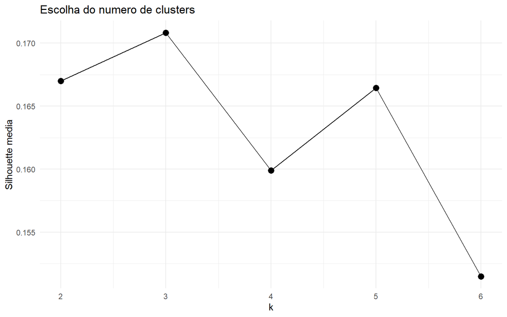

```r
ggplot(sil_df, aes(x = k, y = silhouette_media)) +
  geom_line() +
  geom_point(size = 3) +
  theme_minimal() +
  labs(
    title = "Escolha do numero de clusters",
    x = "k",
    y = "Silhouette media"
  )
```

## Interpretação da fase 2

As análises não supervisionadas permitiram-nos observar a estrutura global dos dados sem impor grupos de antemão. Em particular, PCA e MDS ajudam-nos a perceber se as amostras tumorais e normais apresentam separação global consistente.

O heatmap dos genes mais variáveis ajuda nesta leitura pois destaca padrões de coexpressão e possíveis blocos de amostras com comportamento semelhante. Quando a organização das amostras acompanha o tipo de tecido, isso acaba por reforçar a presença de diferenças transcriptómicas robustas.

A análise restrita dos tumores permite-nos examinar a heterogeneidade interna do grupo tumoral. O clustering por K-means, apoiada pela métrica de silhouette, constitui uma análise preliminar útil para a identificação de subgrupos potencialmente associados a variáveis clínicas como o Gleason score, o estado livre de doença ou a fração do genoma alterado.

# 6 Discussão geral

Os resultados que obtivemos demonstram que o conjunto TCGA-PRAD é sim adequado para análise integrada de expressão génica e metadados clínicos. Ao comparar tecido tumoral com o tecido normal podemos identificar genes diferencialmente expressos e também explorar alguns marcadores de interesse reconhecidos no contexto do cancro da próstata.

A integração da análise de enriquecimento funcional faz com que a interpretação dos resultados se torne mais robusta, ao permitir identificar processos biológicos e vias moleculares sobre-representadas entre os genes alterados. Desta forma, a análise passa de se centrar apenas em genes isolados para agora considerar mecanismos biológicos mais amplos.

As análises não supervisionadas demonstram ainda que existem estruturas nos dados e possivel heterogeneidade dentro do conjunto tumoral. Apesar destas abordagens serem exploratórias, estas constituem uma base importante para etapas futuras de modelação preditiva e seleção de genes.

# 7 Conclusão

Durante o trabalho desenvolvemos um pipeline reprodutível em R/Bioconductor para a análise de dados de expressão génica no conjunto TCGA-PRAD. Realizamos tarefas de preparação e pré-processamento, análise descritiva, testes univariados, análise de expressão diferencial, enriquecimento funcional e análises não supervisionadas.

No contexto global os resultados sugerem diferenças transcriptómicas relevantes entre tumor primário e tecido normal, bem como heterogeneidade entre tumores. os resultados obtidos sustentam a continuação do trabalho para a próxima fase, sendo essa centrada e análise preditiva e seleção de genes.

#Fase 3

Preparação dos Dados: Seleção dos 100 genes com maior significância estatística (menor padj na análise diferencial) para reduzir a dimensionalidade e focar em preditores robustos.

Treino e Avaliação: Divisão dos dados em conjuntos de treino (70%) e teste (30%). Implementámos dois modelos de aprendizagem automática: Random Forest e SVM (Support Vector Machines), utilizando validação cruzada (5-fold cross-validation) para otimização e comparação de desempenho através da métrica ROC.

Seleção de Genes: Extração da importância das variáveis do modelo Random Forest para identificar os genes com maior peso na classificação das amostras, cruzando estes dados com anotações biológicas para interpretação funcional.

```r
library(caret)
library(randomForest)
library(e1071)
library(pROC)

# 1. Selecionar os IDs Ensembl dos top 100 genes baseados no padj
top_ensembl_ids <- res_annot %>%
  filter(!is.na(padj)) %>%
  arrange(padj) %>%
  head(100) %>%
  pull(ensembl)

# 2. Localizar a posição (índice) destes genes na estrutura original
# Usamos o objeto 'anot' que mapeia Ensembl -> Posição na matriz
top_indices <- match(top_ensembl_ids, anot$ensembl)

# Remover possíveis NAs (genes que podem ter sido filtrados antes da VST)
top_indices <- top_indices[!is.na(top_indices)]

# 3. Preparar a matriz de dados (Transpor: amostras nas linhas, genes nas colunas)
# Usar índices numéricos [top_indices, ] evita o erro de nomes não encontrados
ml_data <- as.data.frame(t(vst_mat[top_indices, , drop = FALSE]))

# 4. Adicionar a variável alvo (Classe: NT ou TP)
# Garantir que a ordem das classes corresponde às amostras na matriz
ml_data$Class <- factor(meta2$shortLetterCode[match(rownames(ml_data), meta2$sample_id)])

# 5. Limpeza de nomes de colunas (R transforma nomes de genes com caracteres especiais)
colnames(ml_data) <- make.names(colnames(ml_data))

# 6. Divisão Treino/Teste (70% treino, 30% teste)
set.seed(123)
# O caret precisa do pacote instalado: install.packages("caret")
library(caret)
trainIndex <- createDataPartition(ml_data$Class, p = 0.7, list = FALSE)
train_set <- ml_data[trainIndex, ]
test_set  <- ml_data[-trainIndex, ]
```

```r
# Configuração do treino: 5-fold Cross-Validation
train_control <- trainControl(method = "cv", number = 5, classProbs = TRUE, summaryFunction = twoClassSummary)

# --- Modelo A: Random Forest ---
set.seed(123)
model_rf <- train(
  Class ~ .,
  data = train_set,
  method = "rf",
  trControl = train_control,
  metric = "ROC",
  importance = TRUE
)

# --- Modelo B: SVM (Linear Kernel) ---
set.seed(123)
model_svm <- train(
  Class ~ .,
  data = train_set,
  method = "svmLinear",
  trControl = train_control,
  metric = "ROC",
  preProcess = c("center", "scale")
)

# Comparação de resultados no treino
results <- resamples(list(RF = model_rf, SVM = model_svm))
summary(results)
```

```
##
## Call:
## summary.resamples(object = results)
##
## Models: RF, SVM
## Number of resamples: 5
##
## ROC
##          Min.   1st Qu.    Median      Mean   3rd Qu.      Max. NA's
## RF  0.8964286 0.9500000 0.9571429 0.9576308 0.9899396 0.9946429    0
## SVM 0.9224490 0.9321429 0.9346939 0.9492807 0.9732143 0.9839034    0
##
## Sens
##          Min.   1st Qu. Median      Mean   3rd Qu.      Max. NA's
## RF  0.5714286 0.6250000  0.625 0.6500000 0.7142857 0.7142857    0
## SVM 0.7142857 0.7142857  0.750 0.7821429 0.8571429 0.8750000    0
##
## Spec
##          Min.   1st Qu.    Median      Mean 3rd Qu. Max. NA's
## RF  0.9714286 0.9859155 1.0000000 0.9914688       1    1    0
## SVM 0.9428571 0.9857143 0.9859155 0.9828974       1    1    0
```

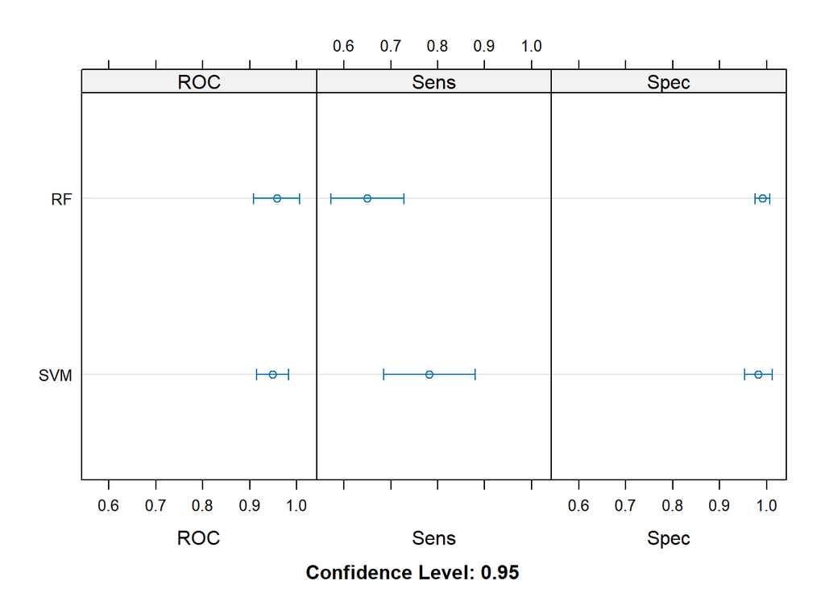

```r
dotplot(results)
```

#Desempenho dos Modelos Este gráfico compara o desempenho dos modelos Random Forest (RF) e Support Vector Machine (SVM) através de três métricas: Área sob a Curva ROC, Sensibilidade (Sens) e Especificidade (Spec).

```r
# Previsões
pred_rf <- predict(model_rf, test_set)
pred_svm <- predict(model_svm, test_set)

# Matrizes de Confusão
cat("--- Performance Random Forest ---\n")
```

```
## --- Performance Random Forest ---
```

```r
confusionMatrix(pred_rf, test_set$Class)
```

```
## Confusion Matrix and Statistics
##
##           Reference
## Prediction  NT  TP
##         NT  10   1
##         TP   5 149
##
##                Accuracy : 0.9636
##                  95% CI : (0.9225, 0.9865)
##     No Information Rate : 0.9091
##     P-Value [Acc > NIR] : 0.005774
##
##                   Kappa : 0.75
##
##  Mcnemar's Test P-Value : 0.220671
##
##             Sensitivity : 0.66667
##             Specificity : 0.99333
##          Pos Pred Value : 0.90909
##          Neg Pred Value : 0.96753
##              Prevalence : 0.09091
##          Detection Rate : 0.06061
##    Detection Prevalence : 0.06667
##       Balanced Accuracy : 0.83000
##
##        'Positive' Class : NT
##
```

```r
cat("\n--- Performance SVM ---\n")
```

```
##
## --- Performance SVM ---
```

```r
confusionMatrix(pred_svm, test_set$Class)
```

```
## Confusion Matrix and Statistics
##
##           Reference
## Prediction  NT  TP
##         NT  10   6
##         TP   5 144
##
##                Accuracy : 0.9333
##                  95% CI : (0.8838, 0.9663)
##     No Information Rate : 0.9091
##     P-Value [Acc > NIR] : 0.1722
##
##                   Kappa : 0.6084
##
##  Mcnemar's Test P-Value : 1.0000
##
##             Sensitivity : 0.66667
##             Specificity : 0.96000
##          Pos Pred Value : 0.62500
##          Neg Pred Value : 0.96644
##              Prevalence : 0.09091
##          Detection Rate : 0.06061
##    Detection Prevalence : 0.09697
##       Balanced Accuracy : 0.81333
##
##        'Positive' Class : NT
##
```

```r
# 1. Extrair a importância das variáveis
imp_rf <- varImp(model_rf, scale = FALSE)

# 2. Converter para dataframe e tratar as colunas
imp_df <- as.data.frame(imp_rf$importance)

# Se não houver uma coluna 'Overall', criamos uma com a média das classes
if (!"Overall" %in% colnames(imp_df)) {
  imp_df$Overall <- rowMeans(imp_df)
}

# 3. Ordenar e selecionar os top 20
# O order() agora terá sempre a coluna Overall para trabalhar
top_20_imp <- imp_df[order(imp_df$Overall, decreasing = TRUE), , drop = FALSE]
top_20_imp <- head(top_20_imp, 20)

# 4. Limpar os nomes das linhas (genes)
# O caret/make.names pode ter adicionado um 'X' ou trocado '-' por '.'
genes_no_modelo <- rownames(top_20_imp)
genes_limpos <- gsub("^X", "", genes_no_modelo)
genes_limpos <- gsub("\\.", "-", genes_limpos)

## 5. Criar tabela final e cruzar com anotação (anot)
top_20_data <- data.frame(
  Feature = genes_no_modelo,
  ID_Busca = genes_limpos,
  Importance = top_20_imp$Overall,
  stringsAsFactors = FALSE
)

# Identificar dinamicamente qual é a coluna de IDs e qual é a de Nomes em 'anot'
# Vamos procurar colunas que contenham "ensembl" ou "symbol" (independente de maiúsculas)
col_ensembl <- grep("ensembl", colnames(anot), ignore.case = TRUE, value = TRUE)[1]
col_symbol <- grep("symbol", colnames(anot), ignore.case = TRUE, value = TRUE)[1]

# Tentar o join
if (!is.na(col_ensembl) && any(top_20_data$ID_Busca %in% anot[[col_ensembl]])) {
  # Se os IDs no modelo forem Ensembl
  top_20_genes_final <- left_join(top_20_data, anot, by = c("ID_Busca" = col_ensembl))
} else if (!is.na(col_symbol)) {
  # Se os IDs no modelo forem Symbols (ex: PCA3)
  top_20_genes_final <- left_join(top_20_data, anot, by = c("ID_Busca" = col_symbol))
} else {
  # Caso não encontre correspondência, mantém apenas os dados de importância
  top_20_genes_final <- top_20_data
  warning("Não foi possível cruzar com a tabela 'anot'. Verifique os nomes das colunas.")
}

# 6. Mostrar resultados e o gráfico
print(top_20_genes_final)
```

```
##       Feature   ID_Busca Importance
## 1       GSTM3      GSTM3   5.403081
## 2     HPN.AS1    HPN-AS1   5.379348
## 3      EPHA10     EPHA10   5.107329
## 4       GNAO1      GNAO1   4.964501
## 5       HOXC6      HOXC6   4.735917
## 6  AC074141.1 AC074141-1   4.595789
## 7     PIK3C2G    PIK3C2G   4.569635
## 8         CLU        CLU   4.282185
## 9      SLC2A9     SLC2A9   4.271039
## 10     GPRC5B     GPRC5B   4.190997
## 11       ZIC2       ZIC2   4.186066
## 12       WWC3       WWC3   3.916159
## 13      LRFN1      LRFN1   3.911793
## 14      ABHD6      ABHD6   3.891578
## 15       MCF2       MCF2   3.877479
## 16      GCNT4      GCNT4   3.820555
## 17 AL031123.2 AL031123-2   3.767133
## 18      PCAT7      PCAT7   3.686640
## 19     NKX2.3     NKX2-3   3.402098
## 20    SLC45A2    SLC45A2   3.332199
```

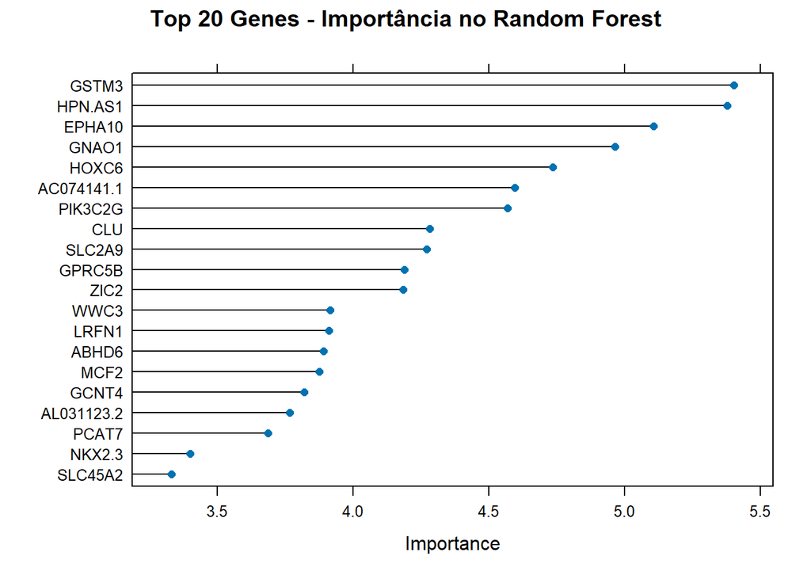

```r
plot(imp_rf, top = 20, main = "Top 20 Genes - Importância no Random Forest")
```

```r
# 6. Mostrar resultados e o gráfico
print(top_20_genes_final)
```

```
##       Feature   ID_Busca Importance
## 1       GSTM3      GSTM3   5.403081
## 2     HPN.AS1    HPN-AS1   5.379348
## 3      EPHA10     EPHA10   5.107329
## 4       GNAO1      GNAO1   4.964501
## 5       HOXC6      HOXC6   4.735917
## 6  AC074141.1 AC074141-1   4.595789
## 7     PIK3C2G    PIK3C2G   4.569635
## 8         CLU        CLU   4.282185
## 9      SLC2A9     SLC2A9   4.271039
## 10     GPRC5B     GPRC5B   4.190997
## 11       ZIC2       ZIC2   4.186066
## 12       WWC3       WWC3   3.916159
## 13      LRFN1      LRFN1   3.911793
## 14      ABHD6      ABHD6   3.891578
## 15       MCF2       MCF2   3.877479
## 16      GCNT4      GCNT4   3.820555
## 17 AL031123.2 AL031123-2   3.767133
## 18      PCAT7      PCAT7   3.686640
## 19     NKX2.3     NKX2-3   3.402098
## 20    SLC45A2    SLC45A2   3.332199
```

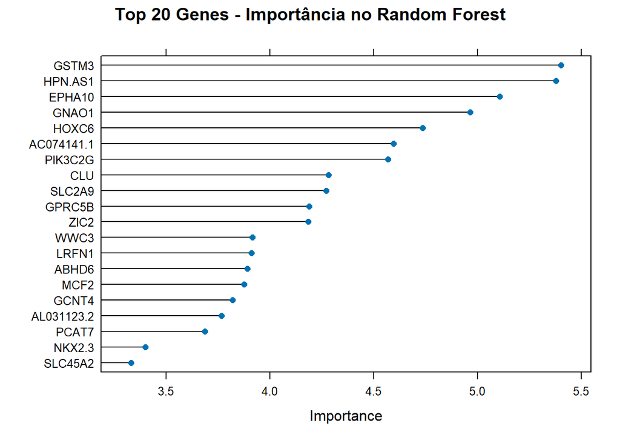

```r
plot(imp_rf, top = 20, main = "Top 20 Genes - Importância no Random Forest")
```

```r
print(top_20_genes_final)
```

```
##       Feature   ID_Busca Importance
## 1       GSTM3      GSTM3   5.403081
## 2     HPN.AS1    HPN-AS1   5.379348
## 3      EPHA10     EPHA10   5.107329
## 4       GNAO1      GNAO1   4.964501
## 5       HOXC6      HOXC6   4.735917
## 6  AC074141.1 AC074141-1   4.595789
## 7     PIK3C2G    PIK3C2G   4.569635
## 8         CLU        CLU   4.282185
## 9      SLC2A9     SLC2A9   4.271039
## 10     GPRC5B     GPRC5B   4.190997
## 11       ZIC2       ZIC2   4.186066
## 12       WWC3       WWC3   3.916159
## 13      LRFN1      LRFN1   3.911793
## 14      ABHD6      ABHD6   3.891578
## 15       MCF2       MCF2   3.877479
## 16      GCNT4      GCNT4   3.820555
## 17 AL031123.2 AL031123-2   3.767133
## 18      PCAT7      PCAT7   3.686640
## 19     NKX2.3     NKX2-3   3.402098
## 20    SLC45A2    SLC45A2   3.332199
```

#Importância de Genes Este gráfico de dot plot apresenta os Top 20 genes que mais contribuem para a capacidade preditiva do modelo Random Forest.

Significado: Os genes no topo da lista (como GSTM3 e HPN.AS1) são os que possuem maior poder discriminatório entre as classes. Isto significa que, para o modelo, os níveis de expressão destes genes são os fatores mais determinantes para classificar corretamente uma amostra como normal ou tumoral.

Interpretação: Estes genes são candidatos fortes a biomarcadores para o adenocarcinoma de próstata. O facto de estarem no topo sugere que a sua desregulação é altamente consistente entre as amostras tumorais comparativamente às normais.